# 1262022_analysis

Tanvi Ingle

1/27/2022

### **Objective**

Here I will analyze the results from the promoter optimization run on 1-26-2022. For this optimization attempt, I ran 5 scenarios with unique distributions for promoters A, B, and D. Each scenario was simmulated 10 times. Each simulation was run for 300 generations.

Here are the details of each run. Each value represents the exponent on *e*, ie if uA = 11, then the mean strength of promoter A is e^11.

> Starting promoter distributions

| scenario | uA | oA | uB | oB | uD | oD |
| --- | --- | --- | --- | --- | --- | --- |
| A | 11.00 | 10 | 12.80 | 10 | 12.30 | 11 |
| B | 11.80 | 10 | 13.50 | 12 | 12.80 | 11 |
| C | 12.21 | 10 | 14.33 | 12 | 14.11 | 11 |
| D | 12.80 | 10 | 14.80 | 12 | 14.50 | 11 |
| E | 13.20 | 10 | 15.40 | 12 | 14.80 | 11 |

### **Dive into Scenario A**

#### **What do the reports for each simulation look like?**

> Scenario A - Change in Error over Generations

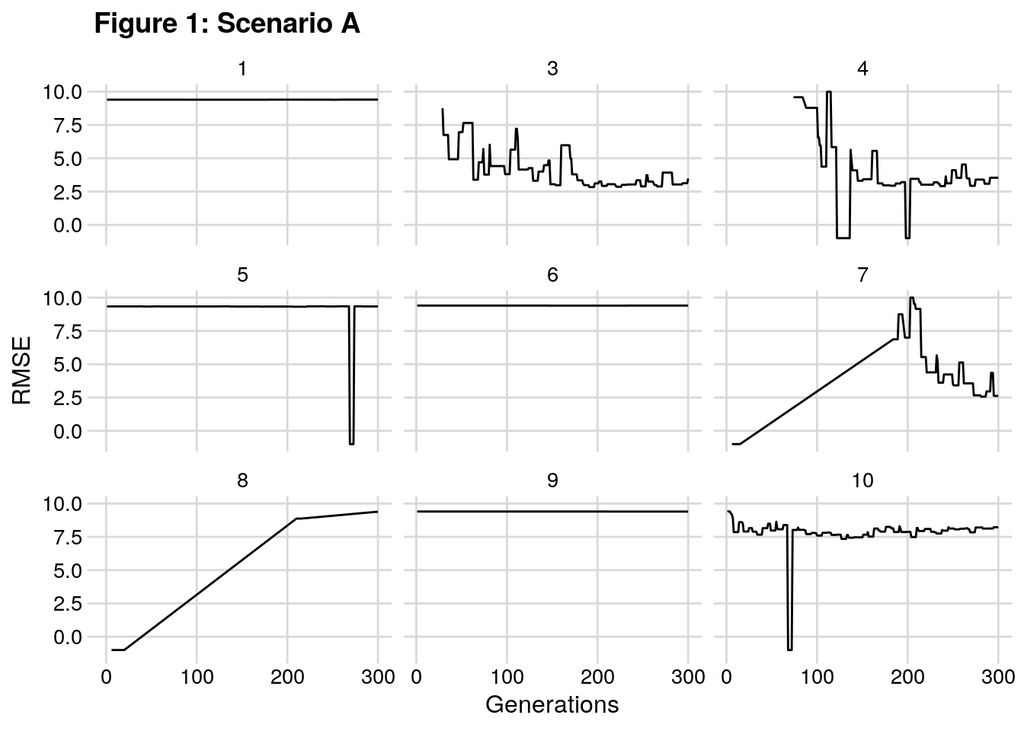

#### **What do the distributions look like for the lowest error simulations?**

> Scenario A - Associated Errors for the best simulations

For Scenario A, simulations 3, 4, 7, and 10 had the lowest errors at the 300th generation.

| gen | pA | pB | pD | error | sim |
| --- | --- | --- | --- | --- | --- |
| 300 | 871392.5 | 15033897.1 | 176176733 | 3.47082 | 3 |
| 300 | 816566.8 | 594394.9 | 3175453602 | 3.53530 | 4 |
| 300 | 586754.0 | 12450376.6 | 57183432641 | 2.61829 | 7 |
| 300 | 919414.3 | 595647.6 | 1540429 | 8.21875 | 10 |

For Scenario A, the distributions for sims 3, 4, and 7 are qualitatively the best. Simulation 10 had no expression, revealing that RMSE score alone is not enough to find the best promoter values. **Should I use another error metric? cosine error?** Visually & quantitatively, sim 7 is the best of the Scenario A batch.

> Final Transcript Abundances for the best of Scenario A

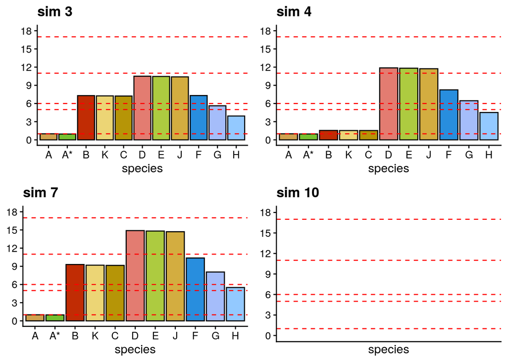

Here is how the sims 3, 4, and 7 change over time (gen 1, gen 150, gen 300). TOP = sim 3, MIDDLE = sim 4, and BOTTOM = sim 7

> Evolution of transcript abundances over generations (Sim 3, 4, 7) - Scenario A

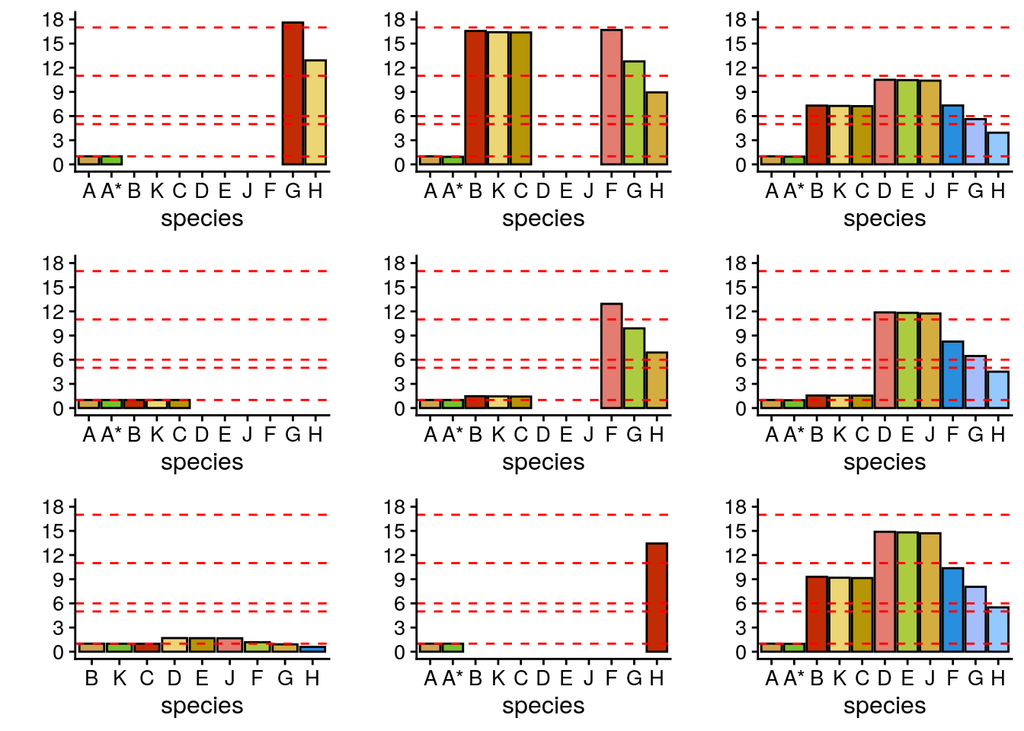

### **Dive into Scenario B**

#### **What do the reports for each simulation look like?**

> Scenario B - Change in Error over Generations

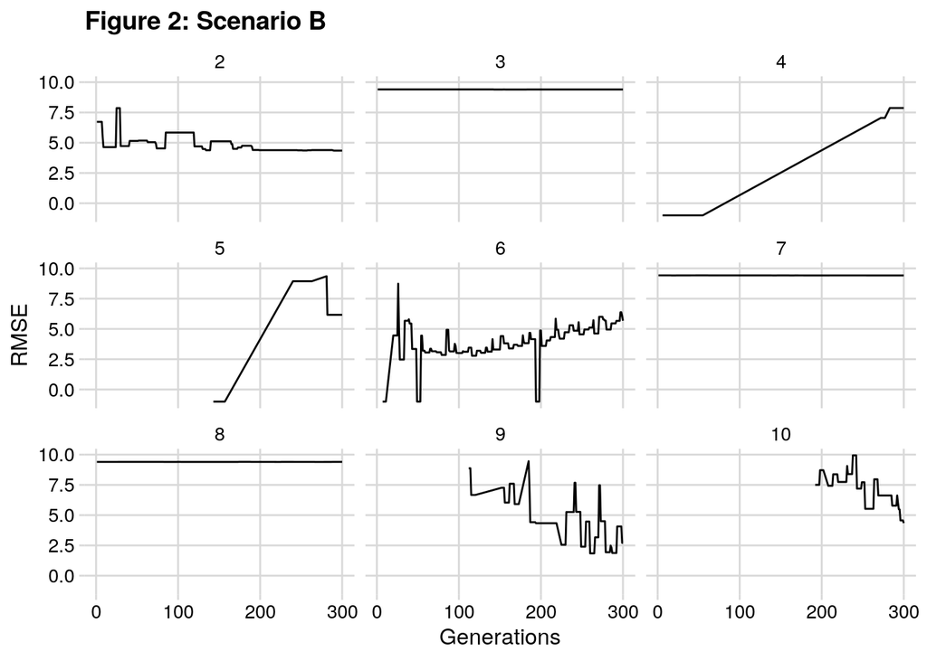

#### **What do the distributions look like for the lowest error simulations?**

For Scenario B, simulations 2, 4, 5, 6, 9, and 10 have the lowest errors at the 300th generation.

> Scenario B - Associated Errors for the best simulations

| gen | pA | pB | pD | error | sim |
| --- | --- | --- | --- | --- | --- |
| 300 | 975647.1 | 2.421673e+09 | 1.269744e+06 | 4.34676 | 2 |
| 300 | 511066.2 | 1.238675e+12 | 1.271191e+06 | 7.86485 | 4 |
| 300 | 471171.6 | 2.875833e+18 | 1.735204e+07 | 6.16749 | 5 |
| 300 | 868910.2 | 6.437813e+06 | 3.502768e+06 | 5.67668 | 6 |
| 300 | 476217.1 | 4.661934e+06 | 1.192904e+12 | 2.71397 | 9 |
| 300 | 686470.6 | 4.734017e+08 | 1.281719e+06 | 4.34402 | 10 |

For Scenario B, the none of the distributions look particularly good – sim 6 looks the best because it captures the step between genes BKC and DEJ. Also, sims 4 and 9 still reported a low error but are missing gene expressions.

> Final Transcript Abundances for the best of Scenario B

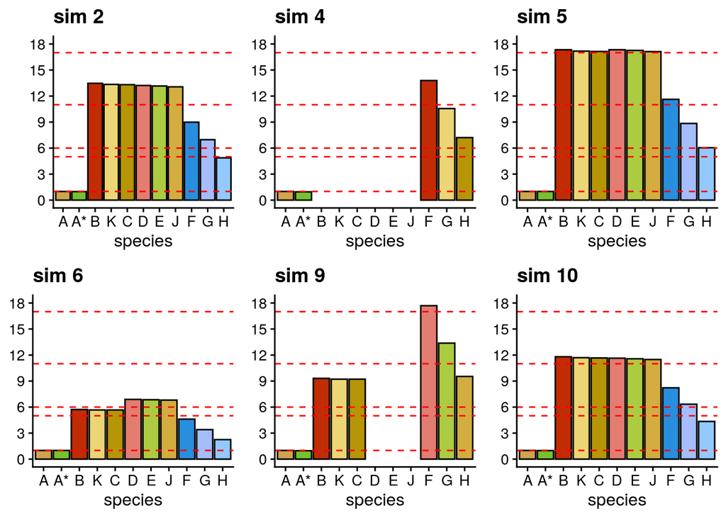

Here is how the sims 2, 4, 5, 6, 9, and 10 change over time (gen 1, gen 150, gen 300).

> Evolution of transcript abundances over generations (Sim 2, 4, 5, 6, 9, 10) - Scenario B

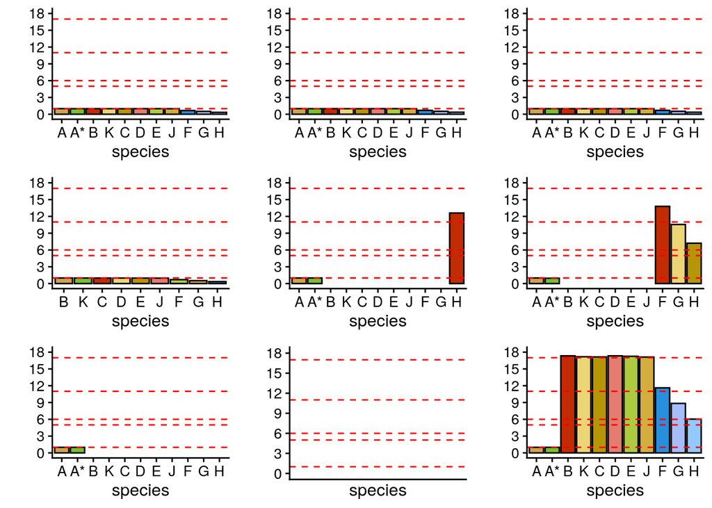

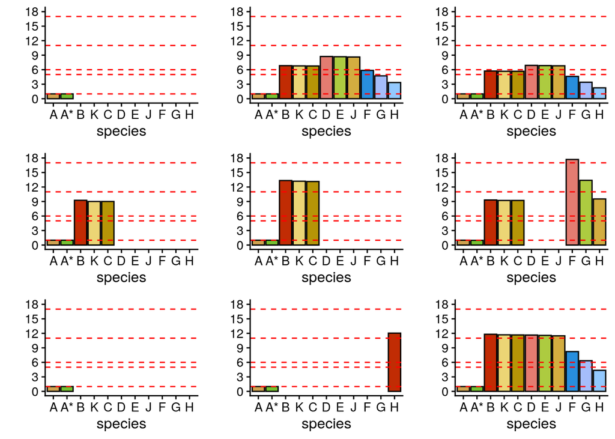

### **Dive into Scenario C**

#### **What do the reports for each simulation look like?**

For Scenario C, I want to explore the parameter space (ie promoter strengths) below what I found manually. First, I look at how the RMSE changes over 300 generations in each of the 10 simulations. Here are my observations:

1. Simulations 1, 3, 6, and 10 have the lowest errors. Simulations 3, 9, and 10 all increase in error for most generations but then decrease towards the end.

> Scenario C - Change in Error over Generations

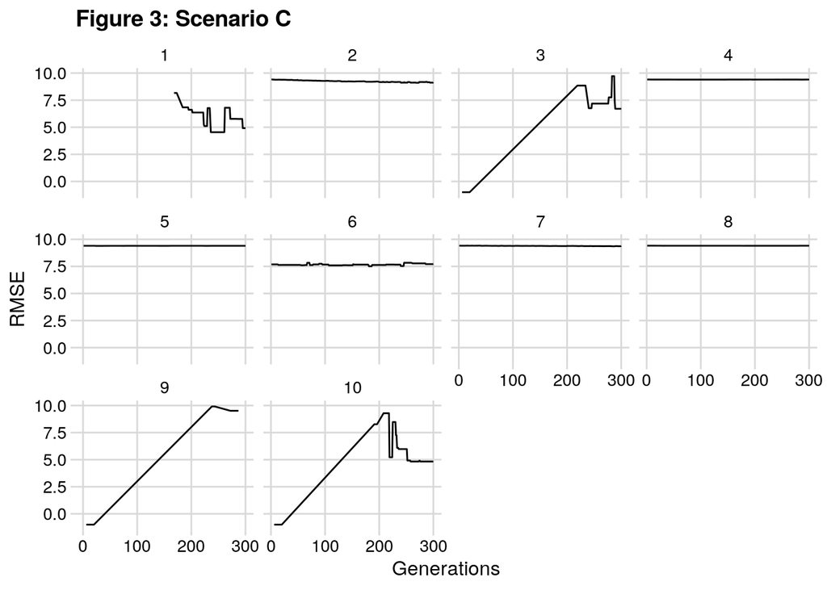

#### **What do the distributions look like for the lowest error simulations?**

For Scenario C, simulations 1, 3, 6, and 10 have the lowest errors at the 300th generation.

> Scenario C - Associated Errors for the best simulations

| gen | pA | pB | pD | error | sim |
| --- | --- | --- | --- | --- | --- |
| 300 | 669392.3 | 5.801758e+13 | 1253509 | 4.91734 | 1 |
| 300 | 584646.7 | 9.065407e+13 | 1491457 | 6.70474 | 3 |
| 300 | 4417646.2 | 2.647037e+13 | 20620091 | 7.70935 | 6 |
| 300 | 648827.0 | 1.435701e+11 | 1594533 | 4.82738 | 10 |

For Scenario C, the none of the distributions look particularly good – sim 1 and sim 10 are the best, however they do not have the step whise increase in gene expression for genes BKC to DEJ. Sim 6 has too low expression levels while sim 3 is missing gene expression for genes BKCDEJ.

> Final Transcript Abundances for the best of Scenario C

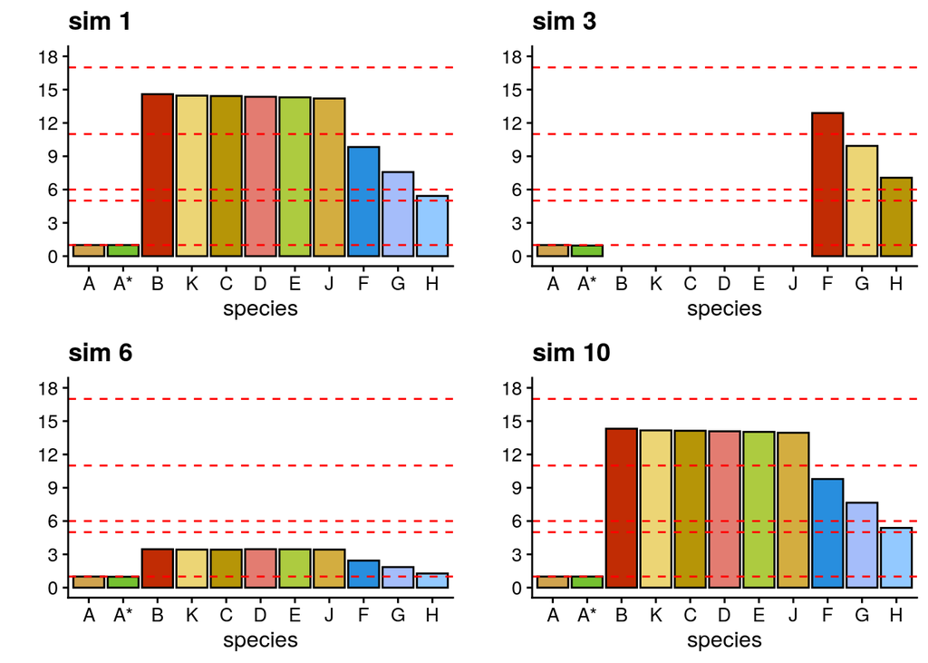

> Evolution of transcript abundances over generations (Sim 1, 3, 6, 10) - Scenario C

Here is how the sims 1, 3, 6, 10 change over time (gen 1, gen 150, gen 300).

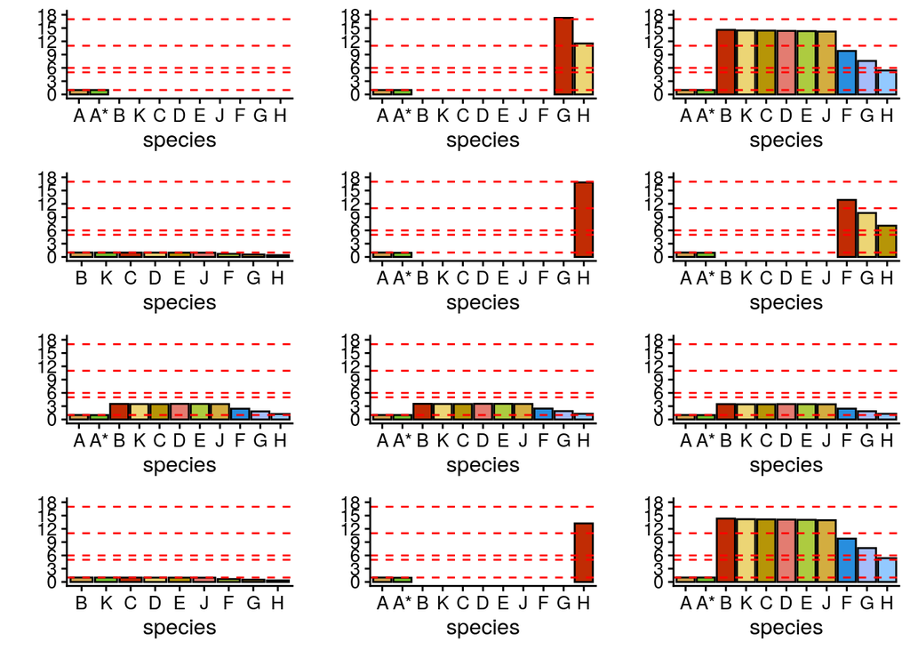

### **Dive into Scenario D**

#### **What do the reports for each simulation look like?**

For Scenario D, I want to explore the parameter space (ie promoter strengths) below what I found manually. First, I look at how the RMSE changes over 300 generations in each of the 10 simulations. Here are my observations:

1. Simulations 3, 7, and 8 have the lowest errors. Simulations 1 and 2 increase in error but never decrease. Scenarios 4, 5, 6, 9, and 10 have an RSME of 9ish.

> Scenario D - Change in Error over Generations

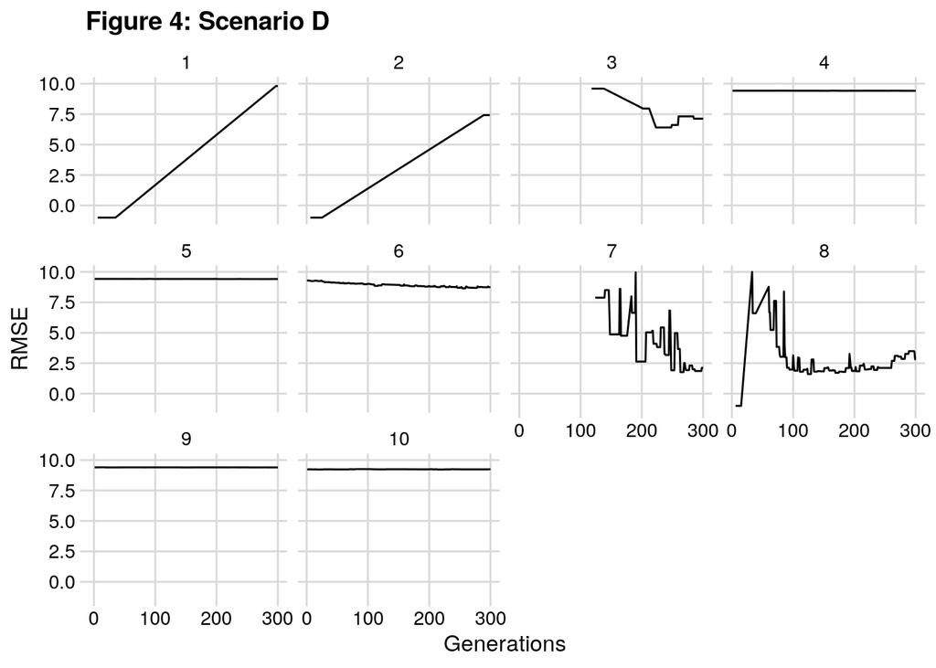

#### **What do the distributions look like for the lowest error simulations?**

| gen | pA | pB | pD | error | sim |
| --- | --- | --- | --- | --- | --- |
| 300 | 1489920806 | 4038221 | 1540743 | 9.41526 | 4 |
| 300 | 293305450 | 4774980 | 1370299 | 9.41426 | 5 |
| 300 | 3911531 | 6430642 | 2281340 | 8.74533 | 6 |
| 300 | 6965340817 | 3319093 | 337441741 | 9.39487 | 9 |
| 300 | 34297220 | 1681505563 | 108097765 | 9.24606 | 10 |

For Scenario D, the none of the distributions look particularly good – at least all of the simulations had all genes expressed. **Why could increasing promoter values result in low transcript abundance levels?**

> Final Transcript Abundances for the best of Scenario D

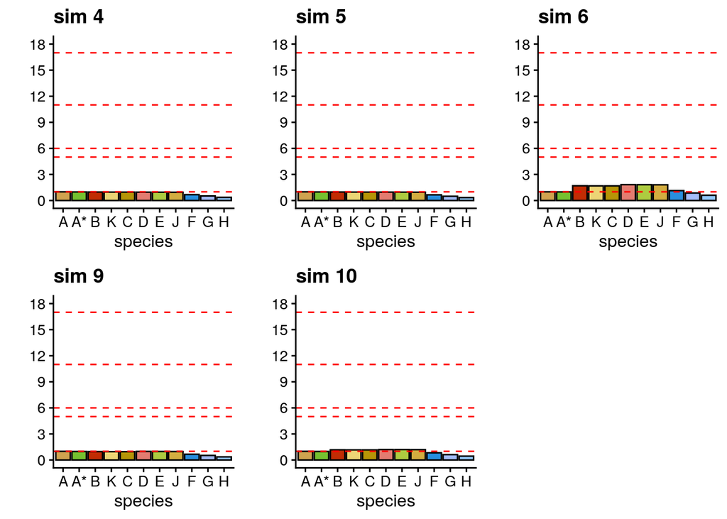

> Evolution of transcript abundances over generations (Sim 4, 5, 6, 9, 10) - Scenario D

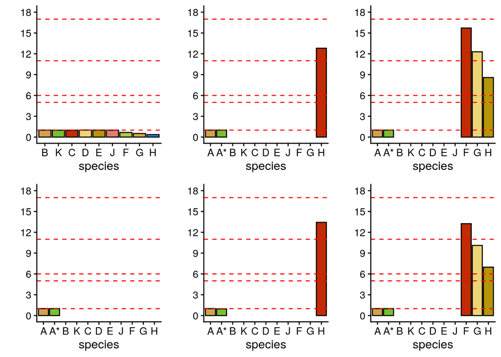

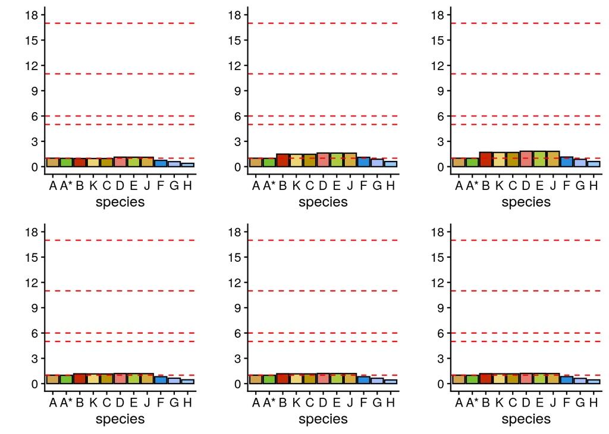

### **Dive into Scenario E**

#### **What do the reports for each simulation look like?**

For Scenario E, I want to explore the parameter space (ie promoter strengths) below what I found manually. First, I look at how the RMSE changes over 300 generations in each of the 10 simulations. Here are my observations:

1. Simulations 2, 4, 8, and 9 have the lowest error. The others all converge around an RMSE of 9ish.

> Scenario E - Change in Error over Generations

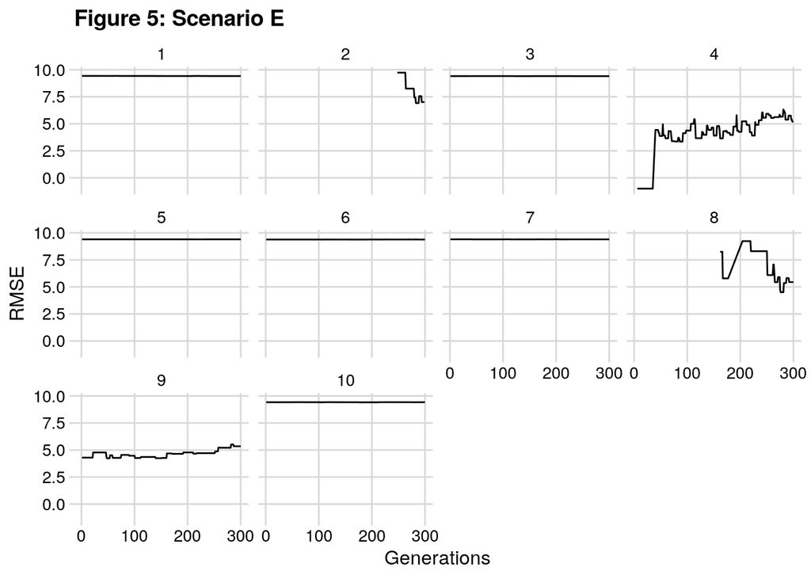

#### **What do the distributions look like for the lowest error simulations?**

For Scenario E, simulations 2, 4, 8, and 9 have the lowest errors at the 300th generation.

> Scenario E - Associated Errors for the best simulations

[output not shown]

For Scenario E, simulation 4 looks good because it captures the step wise increase from BKC to DEJ, yet the abundances for DEJ aren’t high enough. Simulation 8 also looks good since it is high enough, however there is no step wise increase. Simulation 2 is missing expression in genes BKCDEJ and simulation 9 is meh.

> Final Transcript Abundances for the best of Scenario E

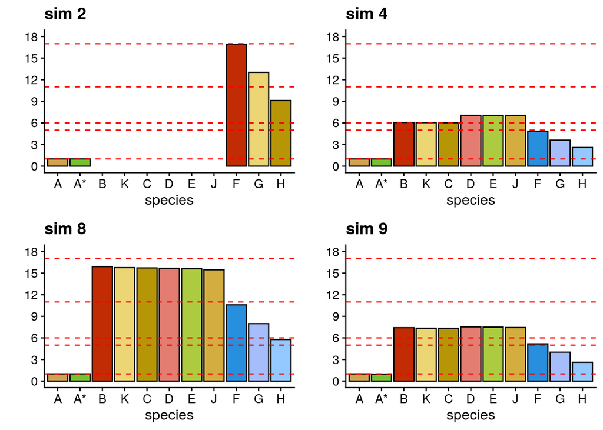

Here is how the sims 2, 4, 8, 9 change over time (gen 1, gen 150, gen 300).

> Evolution of transcript abundances over generations (Sim 2, 4, 8, 9) - Scenario E

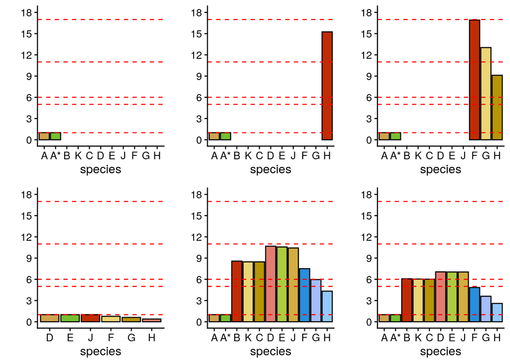

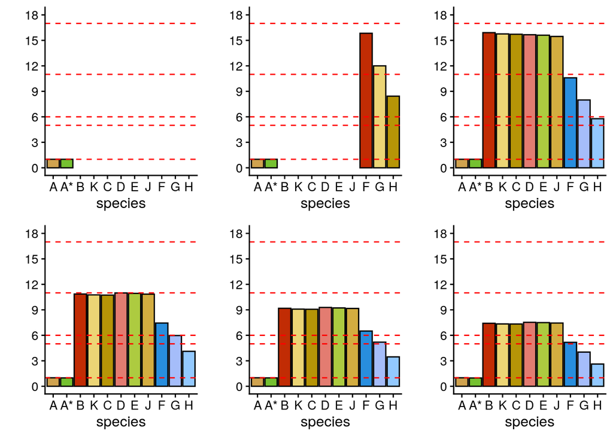